# 絶滅職種図鑑のブランド — 3つの方向 (2026-10-13)

回した体制: ブランド戦略 / アートディレクション / デザインと制作 / 検証 (作った者と別のAI)。同じ中身 (一般事務・減りやすさ98) で3案を作り、1回直して採り直した。外には出していない。

## 結論

- **3案は採点でほぼ同点** (30点満点で A28・B27・C27)。決め手は数字ではなく、あなたの好みと狙い
- 今の「紙・墨・朱」は 9/26 に**世界観をそろえるため**に選んだ物で、効果を比べた記録は無い
- 迷うなら: A を土台に、B の巨大な数字と C の路線の見せ方を移す
- 「あと何年?」は元データに年数が無いので、見出しは「AIで減りやすい?」寄りが安全

## A 紙・墨・朱を磨く (今の延長)

標本・公文書の信頼。今のIG・YT・サイトがこの系なので差し替えが一番少ない。弱点: 押したくなる力が弱い (5/10)

[figure not shown]

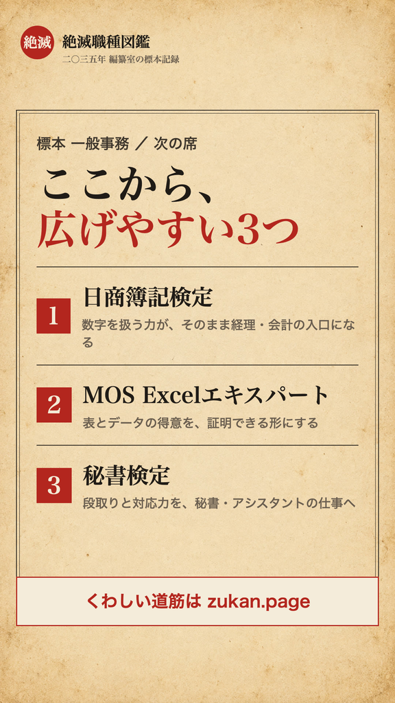

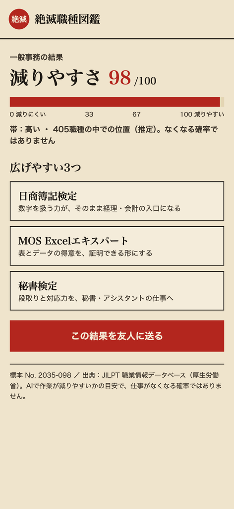

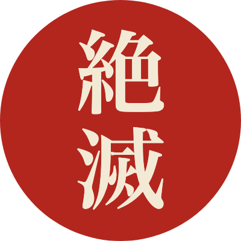

アイコン (丸く切り抜き)

## B 暗地×赤の診断

2秒で自分事。巨大な数字で止める。弱点: ほかと見分けにくい (5/10)。煽りに見えない工夫が要る

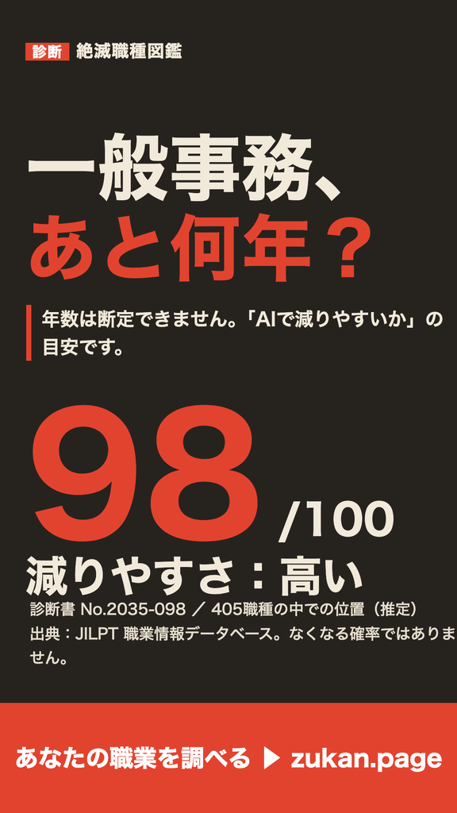

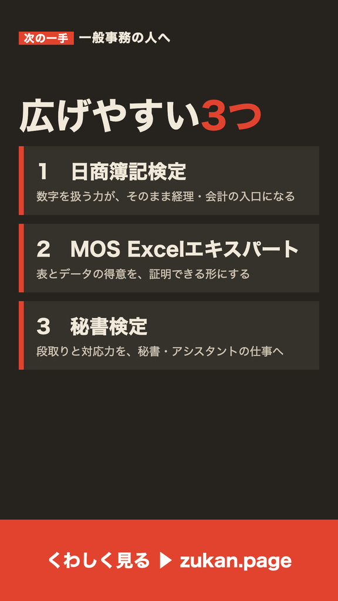

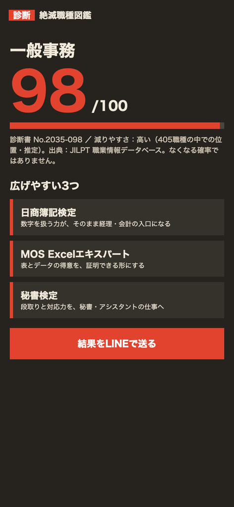

[figure not shown]

アイコン (丸く切り抜き)

## C 白×緑青の路線図

脅さず「次の駅」を見せる。弱点: 信頼が一歩弱い (6/10)。路線の考え方は分かりにくさの指摘あり

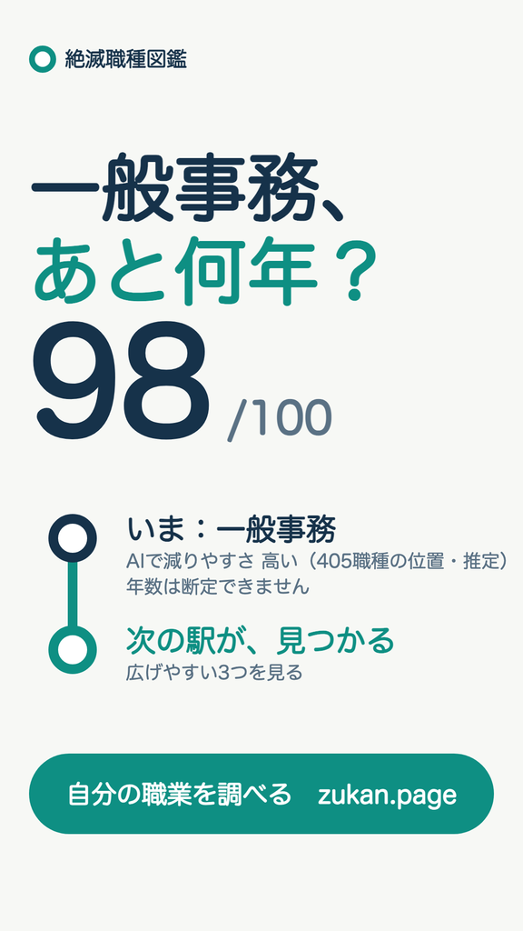

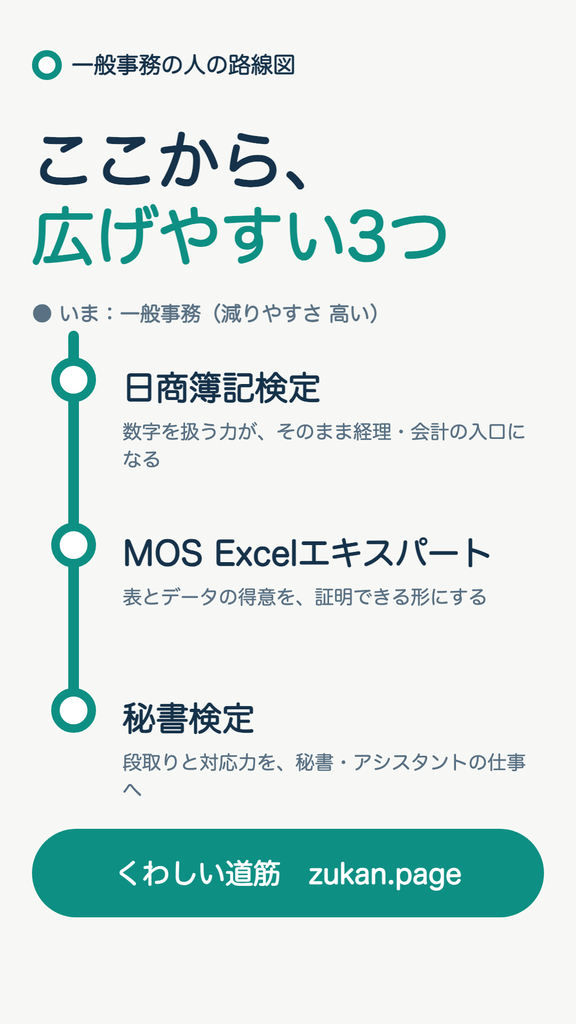

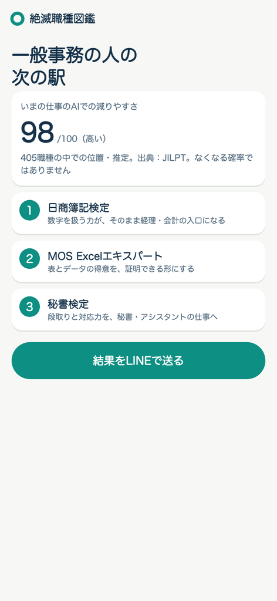

[figure not shown]

アイコン (丸く切り抜き)

## 媒体の棚卸し (ばらばらな所)

- note だけ椅子の写真と「図鑑シリーズ」の名前で、別物に見える (一番目立つずれ)
- Instagram・YouTube・サイトは朱の「絶滅」印でそろっている
- X はログインの壁とアカウント名の記録が無く未確認。TikTok は認証で撮影が不完全

## まだ足りないこと

- お手本 (The Pudding・国立公文書館・NewsPicks など) と**実際の画面を並べた比較はまだ** (名前とURLだけ)
- 差し替えはしていない。選んだ方向で、各媒体のアイコン・ヘッダー・紹介文・サムネイルの型を作ってから差し替える

## 決めてほしいこと (1問)

どの方向にする？

1. A 紙・墨・朱を磨く
2. B 暗地×赤の診断
3. C 白×緑青の路線図
4. A を土台に B の数字・C の路線を混ぜる (迷った時のおすすめ)